# Signal Processing and Machine Learning for Finance Coursework

## 1 Regression Methods

### 1.1 Processing stock price data in Python

#### 1.1.1 Import

```python
import numpy as np
import pandas as pd
from scipy import stats
import matplotlib.pyplot as plt
from statsmodels.tsa.arima_model import ARIMA
from statsmodels.tsa.ar_model import AR
import copy
import warnings
warnings.filterwarnings('ignore')
%matplotlib inline
```

```python
px = pd.read_csv("priceData.csv", index_col="date")

#dropping nan values
px = px.dropna()
```

```python
print(px)
print(type(px))
```

```
            SPX Index
date
02/01/1930      21.18
03/01/1930      21.23
06/01/1930      21.50
07/01/1930      21.31
08/01/1930      21.29
...               ...
15/06/2017    2432.46
16/06/2017    2433.15
19/06/2017    2453.46
20/06/2017    2437.03
21/06/2017    2434.36

[21974 rows x 1 columns]
<class 'pandas.core.frame.DataFrame'>
```

```python
# transform dataframe to series (important for plotting)
px = px["SPX Index"]
# only transform the index to log
logpx = np.log(px)
```

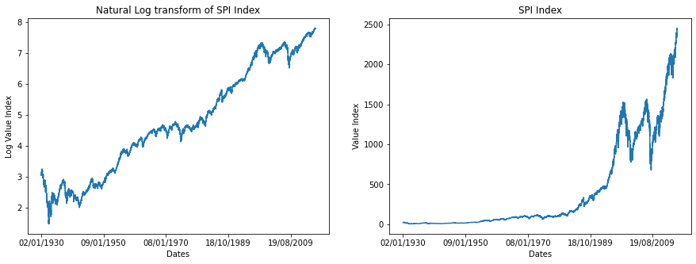

```python
plt.figure(figsize=(15,5))
plt.subplot(1,2,1)
logpx.plot()
plt.title('Natural Log transform of SPI Index')
plt.xlabel('Dates')
plt.ylabel('Log Value Index')

plt.subplot(1,2,2)
px.plot()
plt.title('SPI Index')
plt.xlabel('Dates')
plt.ylabel('Value Index')

plt.show()
```

#### 1.1.2 Sliding Window

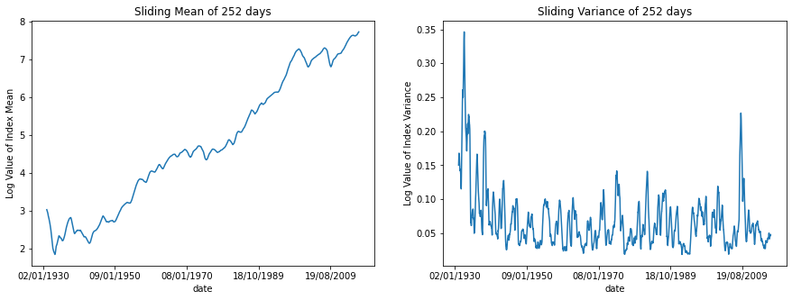

```python
# sliding mean
plt.figure(figsize=(15,5))
plt.subplot(1,2,1)
plt.title('Sliding Mean of 252 days')
plt.xlabel('Dates')
plt.ylabel('Log Value of Index Mean')
logpx.rolling(252).mean().plot()

# sliding standard deviation
plt.subplot(1,2,2)
plt.title('Sliding Variance of 252 days')
plt.xlabel('Dates')
plt.ylabel('Log Value of Index Variance')
logpx.rolling(252).std().plot()
plt.show()
```

#### 1.1.3 Log Return & Simple Return

```python
# log return, diff(): out[i] = arr[i+1] – arr[i]
logret = logpx.diff()
# simple return, pct_change(): Percentage change between the current and a prior element.
simpret = px.pct_change()
```

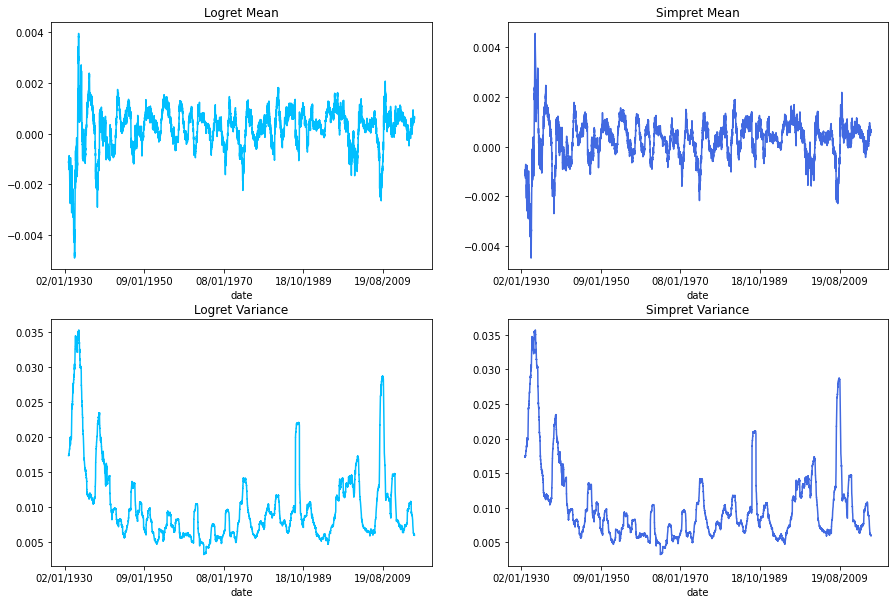

```python
# sliding mean
plt.figure(figsize=(15,10))
plt.subplot(2,2,1)
plt.title('Logret Mean')
logret.rolling(252).mean().plot(color='deepskyblue')

plt.subplot(2,2,2)
plt.title('Simpret Mean')
simpret.rolling(252).mean().plot(color='royalblue')

plt.subplot(2,2,3)
plt.title('Logret Variance')
logret.rolling(252).std().plot(color='deepskyblue')

plt.subplot(2,2,4)
plt.title('Simpret Variance')
simpret.rolling(252).std().plot(color='royalblue')

plt.show()
```

The graphs we see for the sliding windows of the logret and simpret are much more stationary than the first plot we did in 1.1.1 . Therefore we can conclude that the log and simple price return time series is of order one.

#### 1.1.4

Returns are defined as: $$r[t] = \frac{p[t]}{p[t-1]}-1$$ Log-Returns are defined as: $$r[t] = ln(p[t])-ln(p[t-1]) =\log\frac{p[t]}{p[t-1]}$$

As seen in Lecture 2: Log-normality of prices: Over short periods of time, prices tend to be distributed log-normally (1). As a result: $$p[t] \sim \text{log-normal} $$ $$\frac{p[t]}{p[t-1]} \sim \text{log-normal}$$ $$r[t] = \log[\frac{p[t]}{p[t-1]}] \sim \text{normal}$$ r[t] is hence considered to be conveniently normally distributed which is handy since many SP techniques assume normality.

Log return is concentrated around zero, which is convenient. In addition, log compresses the range of data and also conditions the original data. One great effeckt is that we can simply multiply and divide by log values and come back to the original value as compared to non log multiplication followed by division. E.g. for log returns, a 15 % increase in price followed by 15 % decrease results in the initial price, thus reflecting the symmetric behaviour of log returns.

With the help of statsmodels.jarque_bera() method, we can get the jarque bera test for normality and it’s a test based on skewness, and the kurtosis, and has an asymptotic distribution. https://www.statology.org/jarque-bera-test-python/

```python
# return the Jarque−Bera test p−value for a log time−series x
stats.jarque_bera(logret[1:21974])[1]
```

```
0.0
```

```python
# return the Jarque−Bera test p−value for a time−series x
stats.jarque_bera(px[1:21974])[1]
```

```
0.0
```

Since the value is bellow 0.5, we reject the null hypothesis. Thus, we have sufficient evidence to say that this data has skewness and kurtosis that is significantly different from a normal distribution. This does not correspond to our thoughts above about the log return having a normal distribution. If we look at the data we can make the educated guess that this is because of the long timeframe of the data and the big amounts of datapoints.

```python
stats.jarque_bera(logret[920:1000])[1]
```

```
0.5171888035876846
```

```python
# return the Jarque−Bera test p−value for a time−series x
stats.jarque_bera(px[920:1000])[1]
```

```
0.26669014418605297
```

We see that we get a value over 0.5 and thus don't reject the null hypothesis and have sufficient evidence to say that this distribution has skewness and kurtosis of a normal distribution. We also see a difference between the log transformed data and the plain data. We see that the log data are distributed much more like a normal distribution as the plain data.

#### 1.1.5 Stock purchase

We can write ouut the entire calculation and see that the advantage of the log, we see that we come back to the same price.

$$r[1] = \log[\frac{p[t+1]}{p[t]}] = \log[\frac{2}{1}] = 0.69 $$$$r[2] = \log[\frac{p[t+2]}{p[t+1]}] = \log[\frac{1}{2}] = -0.69 $$

Where t is the starting time were the stock was 1£.

So if we have have a positive log return in the first day of 0.69 and the next day the stock falls down to it's original value and we get the negative log return of -0.69 these two values just cancel each other out and we're at the point where we started.

#### 1.1.6 When not to use log returns

- As already seen in 1.1.4 the assumption of log-normality over long time-scales is unrealistic. A positive skew is assumed in log-normal distributions, but most financial data is negatively skewed in long time-scales, owing to financial crashes
- Logarithmic returns are not linearly additive across assets (whereas simple returns are linearly additive)

## 1.2 ARMA vs. ARIMA Models for Financial Applications

```python
snp = pd.read_csv("snp_500_2015_2019.csv")
snp.set_index(['Date'], inplace=True)
snp_close = snp['Close'].to_frame().apply(np.log)
```

```python
snp_close_ts = snp_close['Close'] # transformation from dataframe to series
```

### 1.2.1 Arma or Arima?

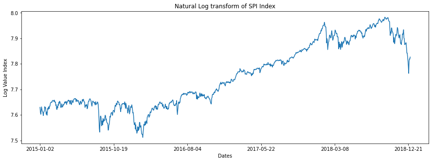

```python
plt.figure(figsize=(15,5))
snp_close_ts.plot()
plt.title('Natural Log transform of SPI Index')
plt.xlabel('Dates')
plt.ylabel('Log Value Index')
```

ARMA models should be used when the data is stationary In case the data shows elements of non-stationarity, a generalization of ARMA is used, i.e. the autoregressive integrated moving average (ARIMA). We can see if the data is non stationary by looking at the sliding window mean and variance as seen above.

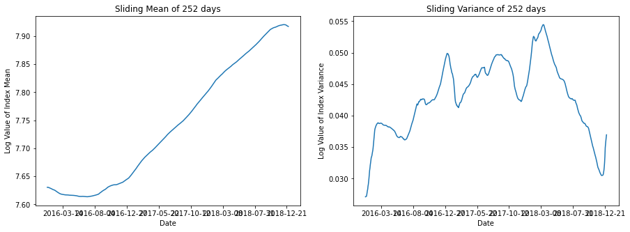

```python
# sliding mean
plt.figure(figsize=(15,5))
plt.subplot(1,2,1)
plt.title('Sliding Mean of 252 days')
plt.xlabel('Dates')
plt.ylabel('Log Value of Index Mean')
snp_close_ts.rolling(252).mean().plot()

# sliding standard deviation
plt.subplot(1,2,2)
plt.title('Sliding Variance of 252 days')
plt.xlabel('Dates')
plt.ylabel('Log Value of Index Variance')
snp_close_ts.rolling(252).std().plot()
plt.show()
```

We see the mean is not stationary and we therefore better use an ARIMA model.

### 1.2.2 Fit Arma model

```python
snp_arma = copy.deepcopy(snp_close)
snp_arma.columns = ['True']
modelarma = ARIMA(snp_arma ,order = (1,0,0)).fit()
snp_arma['Res'] = modelarma.resid
snp_arma_rmse = np.sqrt(np.mean(snp_arma['Res']**2))
snp_arma['Prediction'] = snp_arma['True'] - snp_arma['Res']
```

[output not shown]

```
 This problem is unconstrained.
```

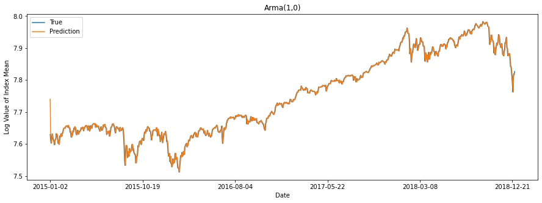

```python
plt.figure(figsize=(15,5))
plt.title('Arma(1,0)')
plt.xlabel('Dates')
plt.ylabel('Log Value of Index Mean')
snp_arma["True"].plot()
snp_arma["Prediction"].plot()
plt.legend(["True","Prediction"])
plt.show()
```

```python
modelarma.params
```

```
const         7.739997
ar.L1.True    0.997359
dtype: float64
```

```python
snp_arma = copy.deepcopy(snp_close)
snp_arma.columns = ['True']
modelarma5 = ARIMA(snp_arma ,order = (4,0,0)).fit()
```

[output not shown]

```
 This problem is unconstrained.
```

```python
modelarma5.params
```

```
const         7.739234
ar.L1.True    0.990555
ar.L2.True   -0.043167
ar.L3.True    0.062720
ar.L4.True   -0.012640
dtype: float64
```

We see that the L1 coefficient is really near to 1 and therefore the next few coefficients would just be really small. Therefore also the optimal model order is 1. In practice we want to be able to predict the price of the index for future values, since the L1 just takes into consideration the last seen value, it is very bad at predicting the future value of the index, so there's no practical value in this model.

### 1.2.3 Arima (1,1,0)

```python
snp_arima = copy.deepcopy(snp_close)
snp_arima.columns = ['True']
modelarima = ARIMA(snp_arima ,order = (1,1,0)).fit()
snp_arima['Res'] = modelarima.resid
snp_arima['Prediction'] = snp_arima['True'] - snp_arima['Res']
```

[output not shown]

```
 This problem is unconstrained.
```

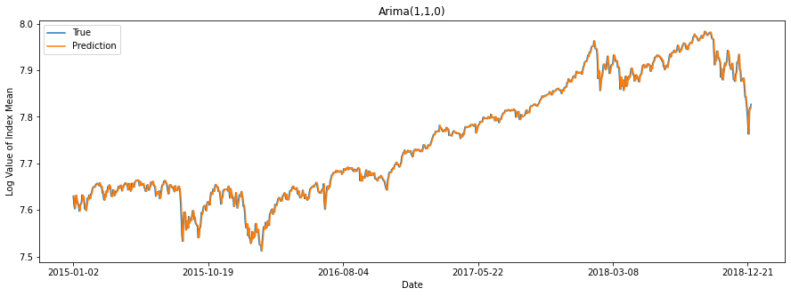

```python
plt.figure(figsize=(15,5))
plt.title('Arima(1,1,0)')
plt.xlabel('Dates')
plt.ylabel('Log Value of Index Mean')
snp_arima["True"].plot()
snp_arima["Prediction"].plot()
plt.legend(["True","Prediction"])
plt.show()
```

We can again look at the RMSE by looking at the residues

```python
snp_arima_rmse = np.sqrt(np.mean(snp_arima['Res']**2))
print("Arma RMSE: ",snp_arma_rmse, "Arima RMSE: ", snp_arima_rmse)
print("Difference: ", snp_arma_rmse-snp_arima_rmse)
```

```
Arma RMSE:  0.009288260126805767 Arima RMSE:  0.008618764909411391
Difference:  0.0006694952173943759
```

Both models fit the data pretty good. We see that the Arima(1,1,0) does a slightly better approximation. Now if we try different arima models with different degrees, we can get some more insights.

```python
snp_arima_rmse_dict = {}
for i in range (0,20):
    snp_arima = copy.deepcopy(snp_close)
    snp_arima.columns = ['True']
    modelarima = ARIMA(snp_arima ,order = (i,1,0)).fit(disp=0)
    snp_arima['Res'] = modelarima.resid
    snp_arima_rmse = np.sqrt(np.mean(snp_arima['Res']**2))
    snp_arima['Prediction'] = snp_arima['True'] - snp_arima['Res']
    snp_arima_rmse_dict[i] = snp_arima_rmse
```

```python
snp_arima_rmse_dict
```

```
{0: 0.008619092241596888,
 1: 0.008618764909411391,
 2: 0.008607195181514937,
 3: 0.008606681441828943,
 4: 0.008587341369335724,
 5: 0.008586955708982822,
 6: 0.008585706715522372,
 7: 0.008584177169524882,
 8: 0.00856277616767019,
 9: 0.00856043096415993,
 10: 0.008559742429132981,
 11: 0.00855797107484998,
 12: 0.008557845678735168,
 13: 0.008557543949305598,
 14: 0.008528452449345155,
 15: 0.008516113090304991,
 16: 0.008513364416898626,
 17: 0.00850202143680456,
 18: 0.008493808007187513,
 19: 0.00848628035589335}
```

### 1.2.4 Why do we take log of prices?

If we take the arima model, we introduce a differentiation term, which as seen in the lecture can be approximated by a difference of two subsequent terms. If we now take the log of these terms, we see that the difference of those will give us back the log return. As already mentioned, stock prices over a short period tend to be log-normally distributed what then makes the log returns behave stationary.

## 1.3 Vector Autoregressive (VAR) Models

### 1.3.1

We can set the matrices as seen in the lecture slides as:

\begin{equation} \textbf{Y} = \begin{pmatrix} y_{1,T-1} & y_{1,T-2} & \cdots & y_{1,0} \\ y_{2,T-1} & y_{2,T-2} & \cdots & y_{2,0} \\ \vdots & \vdots & \ddots & \vdots \\ y_{K,T-1} & y_{K,T-2} & \cdots & y_{K,0} \\ \end{pmatrix} \in R^{K \times T} \end{equation}

\begin{equation} \textbf{A_i} = \begin{pmatrix} c_{1} & a_{1,1}^{i} & a_{1,2}^{i} & \cdots & a_{1,K}^{i}\\ c_{2} & a_{2,1}^{i} & a_{2,2}^{i} & \cdots & a_{2,K}^{i}\\ \vdots & \vdots & \vdots & \ddots & \vdots \\ c_{K} & a_{K,1}^{i} & a_{K,2}^{i} & \cdots & a_{K,K}^{i}\\ \end{pmatrix} \in R^{K \times K} \end{equation}

\begin{equation} \textbf{B} = \begin{pmatrix} \textbf{A_1} & \textbf{A_2} & \cdots & \textbf{A_P} \end{pmatrix} \in R^{K \times (KP + 1)} \end{equation}

\begin{equation} \textbf{Z} = \begin{pmatrix} 1 & 1 & \cdots & 1 \\ y_{1,t-1}^{1} & y_{1,t-2}^{1} & \cdots & y_{1,t-p}^{1} \\ y_{2,t-1}^{1} & y_{2,t-2}^{1} & \cdots & y_{2,t-p}^{1} \\ \vdots & \vdots & \ddots & \vdots \\ y_{K,t-1}^{1} & y_{K,t-2}^{1} & \cdots & y_{K,t-p}^{1} \\ y_{1,t-1}^{2} & y_{1,t-2}^{2} & \cdots & y_{1,t-p}^{2} \\ \vdots & \vdots & \ddots & \vdots \\ y_{K,t-1}^{p} & y_{K,t-2}^{p} & \cdots & y_{K,t-p}^{p} \\ \end{pmatrix} \in R^{(KP + 1) \times T} \end{equation}

\begin{equation} \textbf{U} = \begin{pmatrix} e_{1,T-1} & e_{1,T-2} & \cdots & e_{1,0} \\ e_{2,T-1} & e_{2,T-2} & \cdots & e_{2,0} \\ \vdots & \vdots & \ddots & \vdots \\ e_{K,T-1} & e_{K,T-2} & \cdots & e_{K,0} \\ \end{pmatrix} \in R^{K \times T} \end{equation}

With that we can get the wanted concise form.

### 1.3.2

We can derive this expression by a least squares estimation of $\mathbf{B}$. Since $\mathbf{B}_{opt}$ is the optimal value for $\mathbf{B}$ the error term $\mathbf{U}$ has therefore to be minimized in a least squares fasion.

Our aim therefore is to minimize: $$\mathbf{U}^{T}\mathbf{U}$$

At first we need to rearange our equation to get $\mathbf{U} = \mathbf{Y} - \mathbf{B}\mathbf{Z}$ and therefore: $$\mathbf{U}^{T}\mathbf{U} = (\mathbf{Y} - \mathbf{B}\mathbf{Z})^{T}(\mathbf{Y}- \mathbf{B}\mathbf{Z})$$

Now we have to differentiate $\mathbf{U}^{T}\mathbf{U}$ by $\partial\mathbf{B}$ to get the minimum.

$$\frac{\partial \mathbf{U}^{T} \mathbf{U}}{\partial \mathbf{B}} = \frac{\partial \mathbf{U}^{T}\mathbf{U}}{\partial \mathbf{U}^{T}} \frac{\mathbf{U}^{T}}{\partial \mathbf{B}}$$

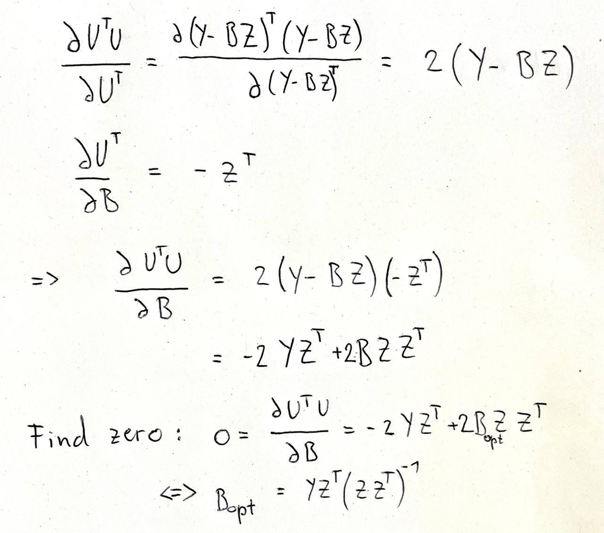

### 1.3.3

If we use equation 6 and insert it into 7 we see that we an inductively continue this to infinity. Therefore the effects of the eigenvalues of A have to be considered. Since we know that for a stable system the eigenvalues have to be less than 1 in absolute value for the system to be stable according to the Ralph-Hurwitz Criterion. To give a better idea one can imagine that we have a function with an exponent higher than the absolute value of 1 that describes a system, if we let this system run to infinity the terms will add up more and more and the system will be unstable, since the exponential terms won't die down.

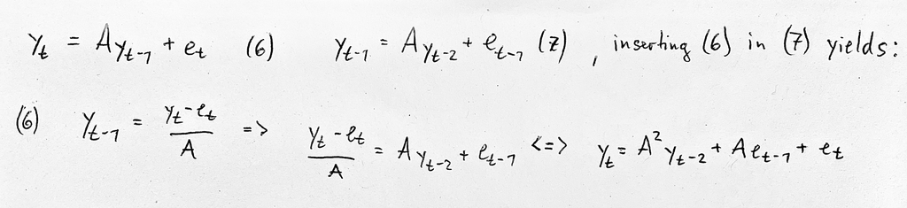

### 1.3.4

```python
import pandas as pd
import matplotlib.pyplot as plt
import numpy as np
import seaborn as sn
from statsmodels.tsa.api import VAR
```

```python
df = pd.read_csv(r'snp_allstocks_2015_2019.csv')
df = df.set_index('Date')
info = pd.read_csv(r'snp_info.csv')
info.drop(columns=info.columns[0], inplace=True)
```

```python
tickers = ['CAG','MAR','LIN','HCP','MAT']
stocks = df[tickers]
stocks_ma = stocks.rolling(window=66).mean()
stocks_detrended = stocks.sub(stocks_ma).dropna()
```

```python
model = VAR(stocks_detrended)
results = model.fit(1)
A = results.params[1:].values
eigA, _ = np.linalg.eig(A)
```

```python
abs(eigA)
```

```
array([0.72609393, 0.72609393, 1.00635964, 0.86051894, 0.91144512])
```

Note that one of the eigenvalues has an absolute value of more than 1. Therefore this model is not stable and it's not a good idea to take up those stocks in the portfolio. We can also look at how correlated this values are, since we would prefer the values to be highly uncorrelated in a portfolio, since we want ot have the best diversification and therefore lowest risk.

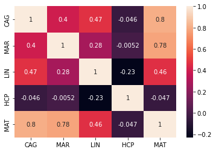

```python
stocks_detrended.corr()
sn.heatmap(stocks_detrended.corr(), annot=True)
plt.show()
```

Looking at this correlation matrix, we see that some stocks are highly corrrelated and we should therefore not construct a portfolio with those values.

### 1.3.5

```python
for sector in info['GICS Sector'].unique():
    tickers = info.loc[info['GICS Sector']==sector]['Symbol'].tolist()
    stocks=df[tickers]
    stocks_ma = stocks.rolling(window=66).mean()
    stocks_detrended = stocks.sub(stocks_ma).dropna()
    model = VAR(stocks_detrended)
    results = model.fit(1)
    A = results.params[1:].values
    eigA, _ = np.linalg.eig(A)
    if (max(abs(eigA)<1)):
        print("Model is stable: ", sector)
    else:
        print("Model is not stable: ", sector)
```

```
Model is stable:  Industrials
Model is stable:  Health Care
Model is stable:  Information Technology
Model is stable:  Communication Services
Model is stable:  Consumer Discretionary
Model is stable:  Utilities
Model is stable:  Financials
Model is stable:  Materials
Model is stable:  Real Estate
Model is stable:  Consumer Staples
Model is stable:  Energy
```